# Probability of seeing sex workers working in other places

Calum Davey, MSc <sup>1</sup>

Jeffrey Dirawo, <sup>2</sup>

Phillis Mushati, MSc <sup>2</sup>

Sitholubuhle Magutshwa, <sup>2</sup>

James Hargreaves, PHD <sup>1</sup>

Frances Cowan, MD <sup>2,3</sup>

20 June, 2018

1. London School of Hygiene and Tropical Medicine, London, UK
2. Centre for Sexual Health and HIV AIDS Research (CeSHHAR) Zimbabwe
3. Liverpool School of Tropical Medicine, Liverpool, UK

Email. calum.davey@lshtm.ac.uk

# Background

Female sex workers are more likely than women of similar age to be living with HIV. Sex work can lead to with violence, stigma, and distrimination. Selling sex is associated with poverty, familial breakdown, substance misuse, and other ‘co-morbid’ vulnerabilities that increase the likelihood that female sex workers will be in need of sustained health and welfare services. Retaining female sex workers in care is a challenge, in part because their work incentivises movement to find clients. A recent impact evaluation of an intervention to improve healthcare services for female sex workers compared places with and without an enhanced sex-worker friendly intervention using respondent-driven-sampling surveys in cross section. Since retention in care and the validity of comparisons between plces to estimate intervention effects will depend on the levels of mobility we sought to model the probability that a female sex worker in Zimbabwe will be in a place different from the location where she usually lives. We used data from the 2016 ‘endline’ survey from the SAPPHIRE trial.

The aim of this analysis was to estimate the overall likelihood of female sex workers being in places other than where they usually live as a function of distance.

# Methods

## Theory

In estimating the probability of observing an individual from location *a* at location *b* we can imagine that this would depend on the probability *p<sub>t</sub>* that women at *a* move for durations away *t*, the distance *d* between *a* and *b*, and the probability, *q<sup>t</sup><sub>d</sub>* of being at such a distance when travelling for duration *t*.

We can estimate *p<sub>t</sub>* by calculating the proportion of the preceeding 12 months that women in our sample spent away on trips of length *t*, i.e. what proportion of the last year was spent on trips of one-weeks duration or less. By geocoding the places visited we were able to calculate the distance *d*. Therefore, the only remaining challenge was to fit models for *q<sup>t</sup><sub>d</sub>*: the probability that a journey of a particular duration *t* would be to a particular distance *d*. We fitted models to frequencies, or counts, of visits for each of four trip-duration bands at 10km distance intervals. To estimate the probability of being found in a particular 10km distance we integrated *q<sup>t</sup><sub>d</sub>* over *d* and *d*-10.

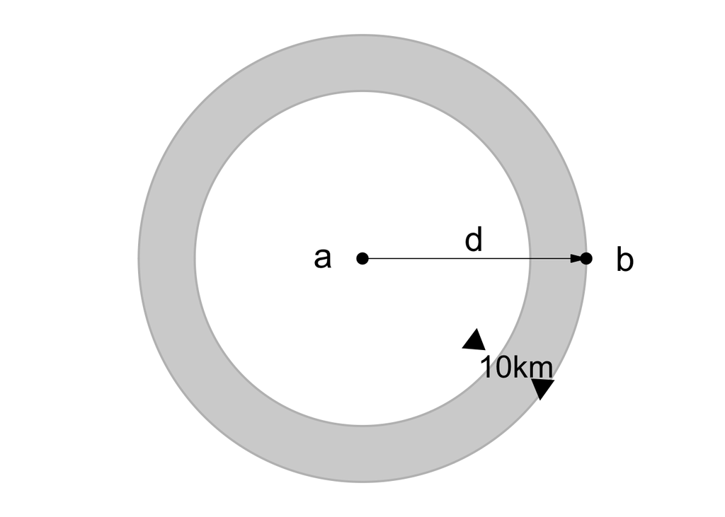

```r
library(shape)
plot.new()
par(mar=c(0,0,0,0), mai=c(0,0,0,0))
plot.window(c(-.6,.6), c(-.6,.6))
plotcircle(r=.4, lcol = "gray", col="light gray")
plotcircle(r=.3, lcol = "gray", col="white")
Arrows(0, 0, .4, 0, code = 2, arr.length = 0.3,
       arr.width = .15, arr.adj = 1, arr.type = "triangle",
       segment = TRUE, col = "black")
textflag(c(-0.07,0), .05, .1, rx = 0, dr = 0.01,
         col = "white", lcol = "white",
         lwd = 2, lab=expression("a"), cex=2)
textflag(c(0.47,0), .05, .1, rx = 0, dr = 0.01,
         col = "white", lcol = "white",
         lwd = 2, lab=expression("b"), cex=2)
textflag(c(0.2,.05), .05, .1, rx = 0, dr = 0.01,
         col = NULL, lcol = NA,
         lwd = 2, lab=expression("d"), cex=2)
filledcircle(r1 = .01, mid = c(0,0), col="black")
filledcircle(r1 = .01, mid = c(0.4,0), col="black")

Arrows(0, 0, .22, -.23, code = 2, arr.length = 0.4,
       arr.width = .5, arr.adj = 1, arr.type = "triangle",
       segment = TRUE, lty=0, col = "black")
Arrows(0.33, -0.33, .301, -.301, code = 2, arr.length = 0.4,
       arr.width = .5, arr.adj = 1, arr.type = "triangle",
       segment = TRUE, lty=0, col = "black")
textflag(c(0.275,-0.27), .05, .1, rx = 0, dr = 0.01,
         col = NULL, lcol = NA,
         lwd = 2, lab=expression("10km"), cex=1.8)
```

## Data

We used data on distances travelled within Zimbabwe.

# Results

## Distance distributions

First we plotted the distances in the data using a histogram.

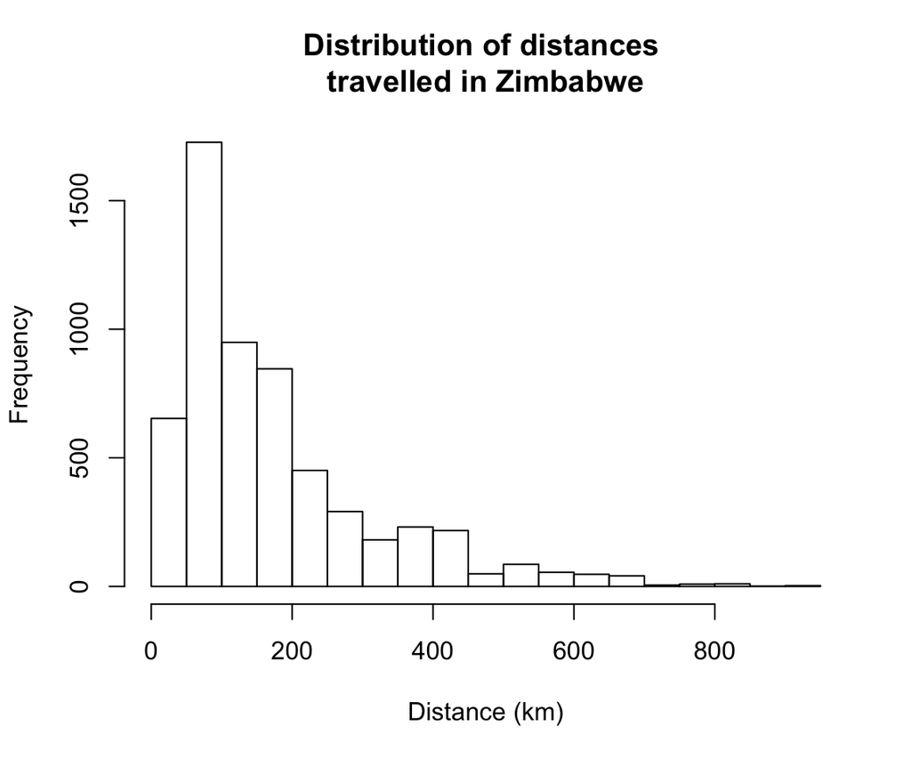

```r
hist(d.z$dist.s2v[d.z$dist.s2v>0 & d.z$v.country=='Zimbabwe'],
     main = 'Distribution of distances \ntravelled in Zimbabwe',
     xlab = 'Distance (km)')
```

We collapsed the distance data into 10km bins and calculated the frequency (count) in each bin and produced the probability density by dividing through by the total number of journeys. We plotted the freqencies separately for travel to places that included sex work (‘work travel’) and travel to places that did not include sex work (‘non-work travel’). The distributions had similar overall shape, with work-travel having a heigher peak around 100 km.

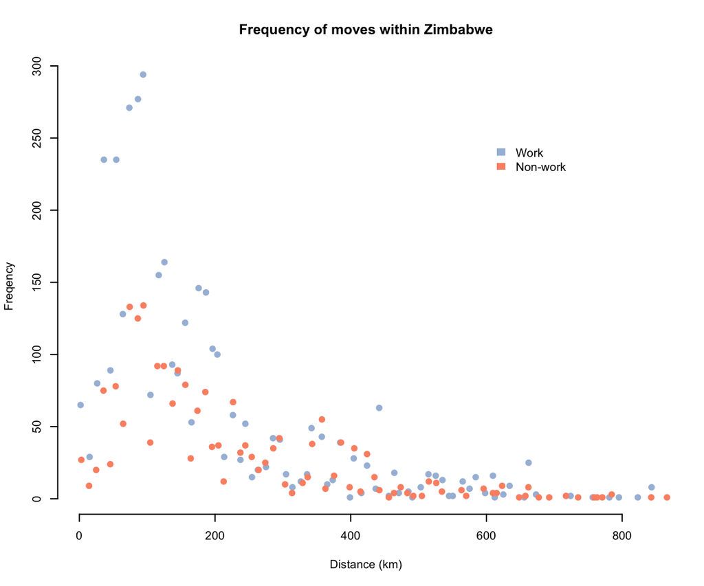

```r
bin <- 10
dists <- d.z  %>%
  filter(v.country=='Zimbabwe') %>%
  mutate(dists = cut(dist.s2v, breaks=seq(0,max(dist.s2v, na.rm=T),bin)),
         type  = ifelse(visit.num<2,1,2)) %>%
  group_by(dists, type) %>%
  summarise(f = sum(!is.na(dist.s2v)),
            d = mean(dist.s2v)) %>%
  .[complete.cases(.),] %>%
  mutate(pf = f/sum(f))

# Colours
library(RColorBrewer)
colour.ramps <- c('PuBu', 'Reds')
colours <- c(brewer.pal(n= 3, name = colour.ramps[1])[2],
             brewer.pal(n= 3, name = colour.ramps[2])[2])
par(pch=19, cex=.6)
plot(f ~ d, frame.plot=FALSE, data=dists[dists$type==1,],col=colours[1],
     main='Frequency of moves within Zimbabwe', xlab='Distance (km)',
     ylab='Freqency')
points(f ~ d, frame.plot=FALSE, data=dists[dists$type==2,], col=colours[2])
legend(x = 600, y = 250, border = NA, legend = c('Work', 'Non-work'),
        fill=colours, bty='n')
```

We suspected that the time spent away would be associated with the distance travelled, and therefore we plotted the frequencies for visits of different durations, for work and non-work travel.

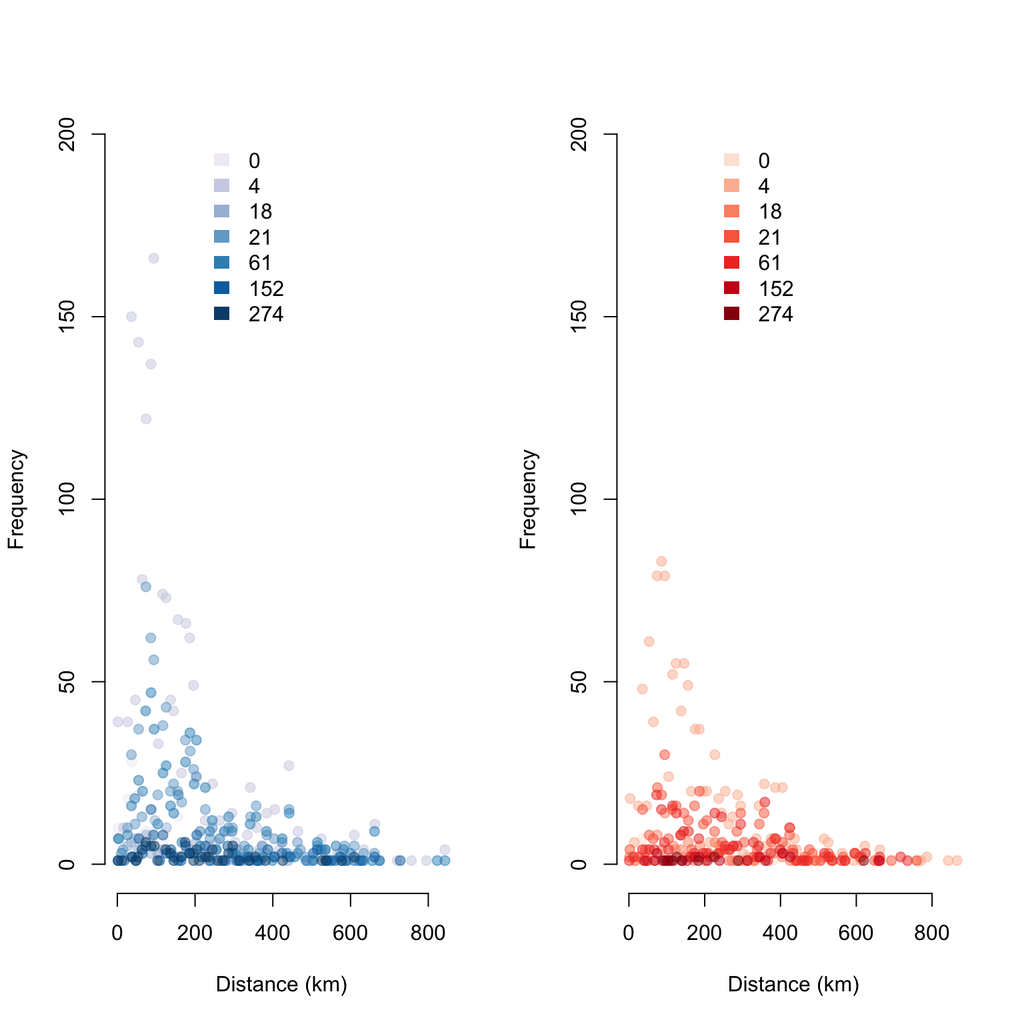

```r
par(pch=19, cex=.4)
layout(matrix(c(1,2), 1, 2, byrow = TRUE))
for (t in 1:2){
  plot(f ~ d, type='n', frame.plot=FALSE, data=dists[dists$type==t,],ylim=c(0,200),
       xlab='Distance (km)', ylab='Frequency')
  j <- 1
  u <- unique(d.z$dura)[!unique(d.z$dura) %in% NA]
  colours <- brewer.pal(n= length(u), name = colour.ramps[t])
  for (i in u[order(u)]) {
    dists1 <- d.z  %>%
      filter(v.country=='Zimbabwe', dura == i) %>%
      mutate(dists = cut(dist.s2v, breaks=seq(0,max(dist.s2v, na.rm=T),bin)),
             type  = ifelse(visit.num<2,1,2)) %>%
      group_by(dists, type) %>%
      #group_by(round(lat1,4), round(lon1,4)) %>%
      summarise(f = sum(!is.na(dist.s2v)),
                d = mean(dist.s2v)) %>%
      .[complete.cases(.),] %>%
      mutate(pf = f/sum(f))
    points(f ~ d, frame.plot=FALSE, data=dists1[dists1$type==t,],
           col=alpha(colours[j],.5))
    j <- j+1
  }
  legend(x = 200, y = 200, border = NA, legend = round(u[order(u)],0),
        fill=colours, bty='n')
}
```

## Fitting models

We tried different models to fit to the data.

First, we tried the simplest model, an exponential fit all of the count data together. Below the peak at around 100km (red line) the exponential model was unable to curve down to zero. Furthermore, the residuals showed evidence of heteroscadiscity.

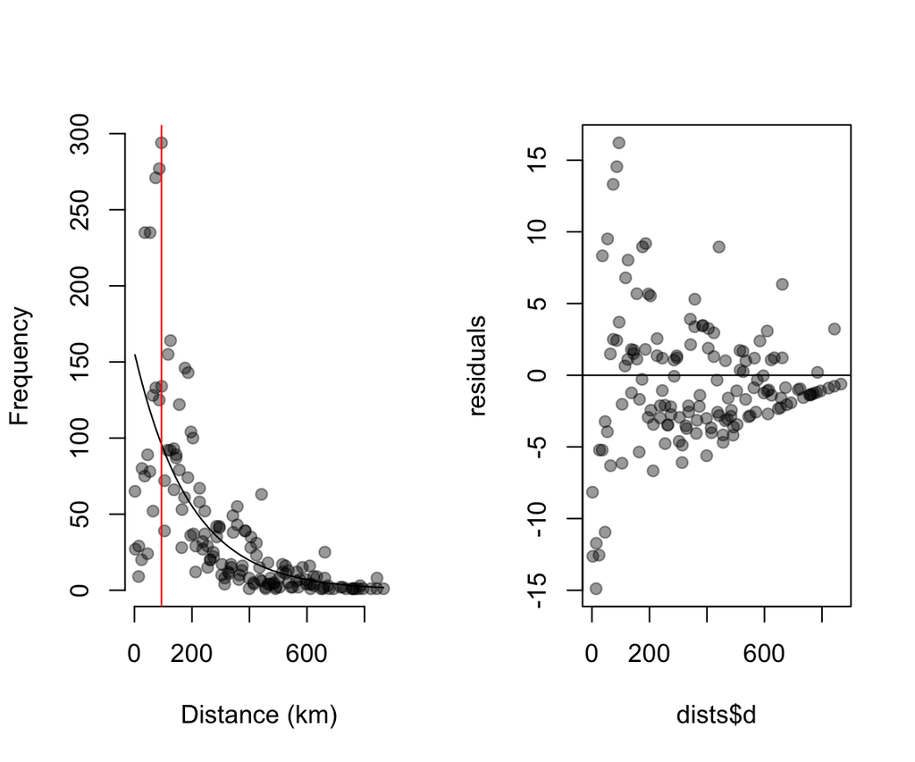

```r
par(pch=19, cex=.4)
layout(matrix(c(1,2), 1, 2, byrow = TRUE))
p <- glm(f ~ d , data = dists, family=poisson(link = "log"))
  plot(dists$f ~ dists$d, frame.plot=FALSE, ylab='Frequency', xlab='Distance (km)',
       col=alpha('black',.4))
  predicted <- predict(p, type = 'r')
  lines(predicted ~ dists$d)
  abline(v = dists$d[dists$f == max(dists$f)], col = 'red')

  residuals <- resid(p)
  plot(residuals ~ dists$d, type='p', col=alpha('black',.4))
  abline(0,0)
```

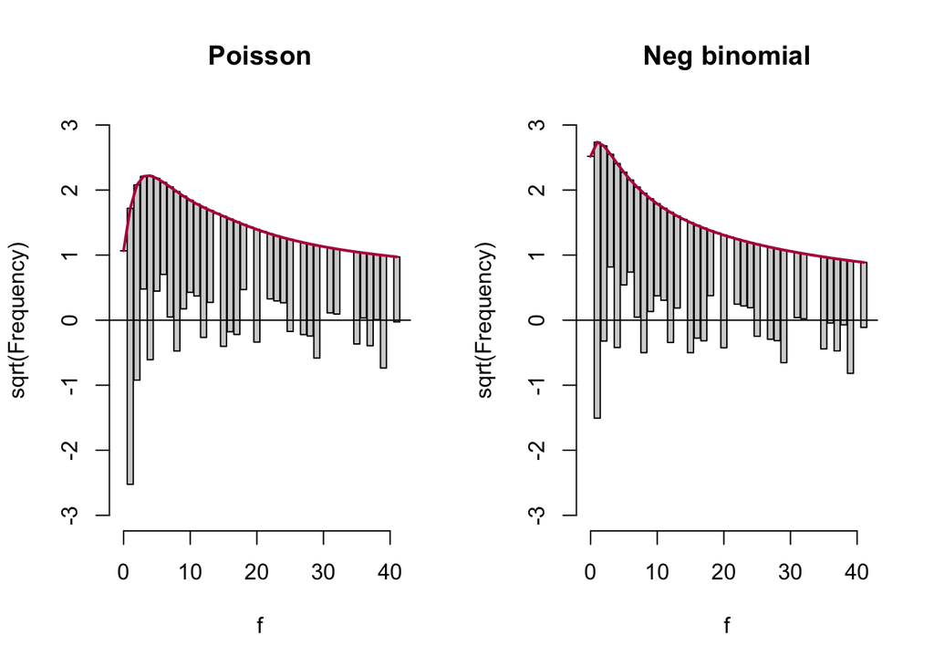

```r
# Check fitting with rootogram
p1 <- glm(f ~ d , data = dists, family=poisson(link = "log"))
p2 <- glm.nb(f ~ d, data = dists)

library('countreg')

par(pch=19, cex=.4)
layout(matrix(c(1,2), 1, 2, byrow = TRUE))
countreg::rootogram(p1, main = 'Poisson', ylim=c(-3,3))
countreg::rootogram(p2, main = 'Neg binomial', ylim=c(-3,3))
```

Therefore, we tried fitting a negative binomial, which reduced the heteroscadiscity relative to the exponential model.

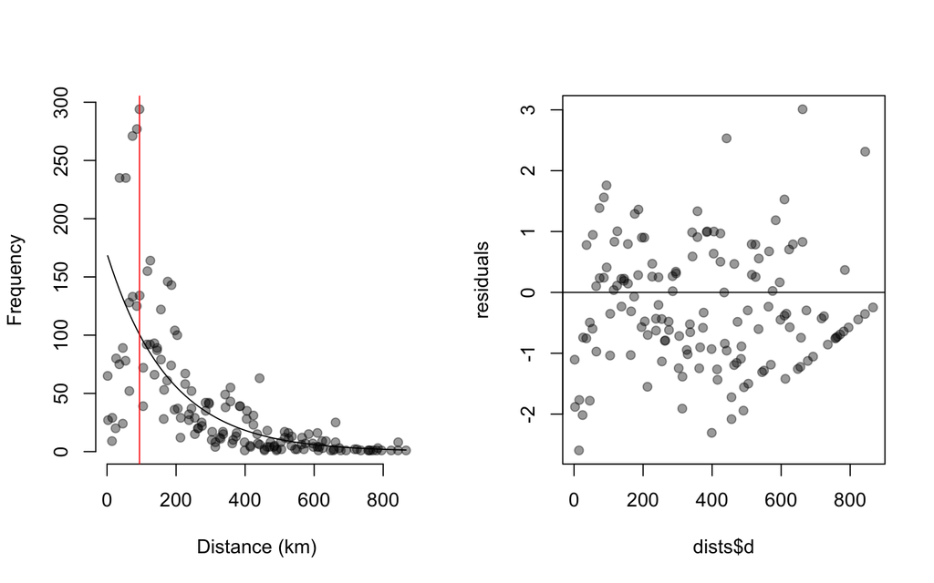

```r
p <- glm.nb(f ~ d, data = dists)

par(pch=19, cex=.4)
layout(matrix(c(1,2), 1, 2, byrow = TRUE))
    plot(dists$f ~ dists$d, frame.plot=FALSE, ylab='Frequency', xlab='Distance (km)',
       col=alpha('black',.4))
  predicted <- predict(p, type = 'r')
  lines(predicted ~ dists$d)
  abline(v = dists$d[dists$f == max(dists$f)], col = 'red')
  residuals <- resid(p)
  plot(residuals ~ dists$d, col=alpha('black',.4))
  abline(0,0)
```

We fitted negative binomial curves for each of the durations away, for work travel and non-work travel, and we combined some of the distances because of the sparseness of the data.

Because there was little data for the 150-274 day non-work journeys we combined these data with the 60-150 trip data.

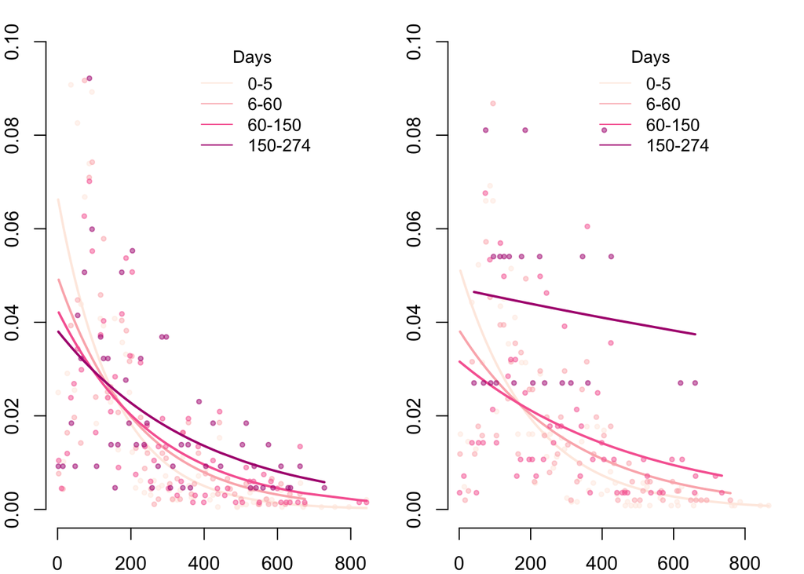

```r
library(modEvA)

delist <- function(x){
  u <- matrix(unlist(x), ncol = 2, byrow=TRUE)
  u <- apply(u, 1, function(x) paste0(x[1],'-',x[2]))
  return(u)
}

# Paraneters to extract from / about the models
a <- c()
r <- c()
d <- c()
inter <- c()
params <- matrix(nrow = 0, ncol = 4)

par(pch=19, cex=1, mar=c(2,2,1,1))
layout(matrix(c(1,2), 1, 2, byrow = TRUE))
u <- list(c(0,5), c(6,60),c(60,150), c(150,ceiling(max(d.z$dura,na.rm = T))))
colours <- brewer.pal(n= length(u), name = 'RdPu')

for (t in 1:2){
  plot(f ~ d, type='n', frame.plot=FALSE, data=dists[dists$type==t,],
       col='green', ylim=c(0,.1), xlab='', ylab='')
  legend(x=350, y=.1, legend=delist(u),col=colours, lty=1, bty='n', cex=.9, title='Days')
  j <- 1
  for (i in 1:length(u)){
    dists1 <- d.z  %>%
      filter(v.country=='Zimbabwe', dura >= u[[i]][1], dura <= u[[i]][2]) %>%
      mutate(dists = cut(dist.s2v, breaks=seq(0,max(dist.s2v, na.rm=T),bin)),
             type  = ifelse(visit.num<2,1,2)) %>%
      filter(type == t) %>%
      group_by(dists) %>%
      #group_by(round(lat1,4), round(lon1,4)) %>%
      summarise(f = sum(!is.na(dist.s2v)),
                d = mean(dist.s2v)) %>%
      .[complete.cases(.),] %>%
      mutate(pf = f/sum(f))
   p <- glm.nb(pf ~ d, data = dists1)
    a <- c(a, AIC(p))
    r <- c(r, modEvA::RsqGLM(p)$McFadden)
    inter <- c(inter, coefficients(p)[1])
    d <- c(d, coefficients(p)[2])
    predicted <- predict(p, type = 'r')
    points(dists1$pf  ~ dists1$d, col = alpha(colours[j],.5), pch=20, cex=.8)
    lines(predicted ~ dists1$d, col = colours[j], lwd = 2)
  j <- j + 1
  params <- rbind(params,
                 c(coefficients(p)[1],
                   summary(p)$coefficients[1, 2],
                   coefficients(p)[2],
                   summary(p)$coefficients[2, 2]))
  }
}
```

```r
# Combine data for 60-274 day non-work visits and replace the parameters
dists1 <- d.z  %>%
  filter(v.country=='Zimbabwe', dura >= u[[3]][1], dura <= u[[4]][2]) %>%
  mutate(dists = cut(dist.s2v, breaks=seq(0,max(dist.s2v, na.rm=T),bin)),
         type  = ifelse(visit.num<2,1,2)) %>%
  filter(type == 2) %>%
  group_by(dists) %>%
  #group_by(round(lat1,4), round(lon1,4)) %>%
  summarise(f = sum(!is.na(dist.s2v)),
            d = mean(dist.s2v)) %>%
  .[complete.cases(.),] %>%
  mutate(pf = f/sum(f))
  p <- glm.nb(pf ~ d, data = dists1)

  params <- rbind(params[1:(nrow(params)-2),],
                 c(coefficients(p)[1],
                   summary(p)$coefficients[1, 2],
                   coefficients(p)[2],
                   summary(p)$coefficients[2, 2]))
```

## Building the probability model

We generated probabilities for each of the 10km distance spans. Then we applied the following steps:

```r
ds <- seq(0,max(d.z$dist.s2v[d.z$visit.num<2 & d.z$v.country=='Zimbabwe'],
                na.rm=T), 10)
# Set using the distances in the data, i.e. interpolating not extrapolating
```

1. Estimate the probability of being on work or non-work travel on trips of different duration

```r
p.away <- d.z %>%
  mutate(type  = ifelse(visit.num<2,1,2)) %>%
  filter(round == 2) %>%
  group_by(type) %>%
  summarise(time.away0 = sum(dura[dura <= u[[1]][2]
                                  & v.country == 'Zimbabwe'], na.rm = T)
            /(365.25*length(unique(id))),
            time.away1 = sum(dura[dura>=u[[2]][1] & dura <= u[[2]][2]
                                  & v.country == 'Zimbabwe'], na.rm = T)
            /(365.25*length(unique(id))),
            time.away2 = sum(dura[dura>=u[[3]][1] & dura <= u[[3]][2]
                                  & v.country == 'Zimbabwe'], na.rm = T)
            /(365.25*length(unique(id))),
            time.away3 = sum(dura[dura>=u[[4]][1]
                                  & v.country == 'Zimbabwe'], na.rm = T)
            /(365.25*length(unique(id))))
p.away <- rbind(t(p.away[1,2:ncol(p.away)]), t(p.away[2,2:ncol(p.away)]))
p.away <- cbind(c(seq(0,7,1),7), c(1-sum(p.away),p.away))
```

2. Choose a model according to probability of being away on any one day
3. Draw intercept and distance coefficient from fitted models
4. Calculate the probability that the journey ended at distance *d*

```r
probs <- matrix(ncol=length(ds),nrow=0)
for (d in ds){
  # For a set number of samples, e
  e <- 1
  prob <- c()
  while (e < 10000){
  # 2. Choose model
  m <- unlist(sample(p.away[,1], size = 1, prob = p.away[,2]))
    if (m != 0){
      # 3. Draw intercepts and distance coefficient from fitted models
      inter <- rnorm(1, mean = params[m,1], sd = params[m,2])
      rho1  <- rnorm(1, mean = params[m,3], sd = params[m,4])
      # 4. Calculate probability journey ended at distance d
      prob <- c(prob, (exp(inter+(rho1*d)-exp(inter+(rho1*(d+10)))) *(10/(2*pi*d))))
    } else {
      prob <- c(prob,0)
    }
  e <- e + 1
  e
  }
 probs <- rbind(probs, prob)
}
probs[probs == Inf | probs == -Inf ] <- 0
```

We plotted the resulting probability distribution.

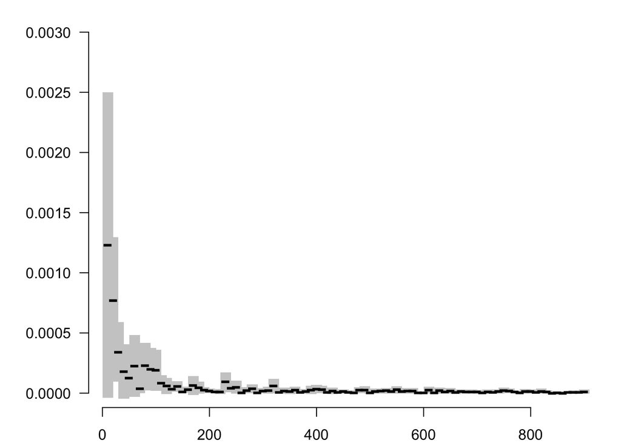

```r
m <- apply(probs, 1, mean)[-1]
par(pch=19, cex=1, mar=c(2,5,1,1))
plot(m ~ ds[-1], type = 'n', ylab='', xlab='Distance (km)', frame.plot=FALSE, ylim=c(0,0.003), las=1)
ci <- cbind(apply(probs, 1, function(x) mean(x) - 1.96*(sd(x)/length(x)^.5)),
            apply(probs, 1, function(x) mean(x) + 1.96*(sd(x)/length(x)^.5)), ds)
shading <- function(x){
  rect(xleft=x[3]-10, xright=x[3]+10, ybottom=x[1], ytop=x[2], border=NA, col='gray80')
}
apply(ci, 1, shading)
points(m ~ ds[-1], pch='-', cex=2)
```

And reported the probabilities for observing one of 100 women in a week for the shorter distances.

```r
t <- cbind(m, ci[-1,])
t <- cbind(t[1:6,1:3]*100*7)
t <- cbind(seq(10,60,10),
           apply(t, 1,
                 function(x)
                   paste0(round(x[1],2),' (',
                   round(x[2],2),'-',
                   round(x[3],2),')')))
colnames(t) <- c('km', 'Probability (95% CI)')
knitr::kable(t, row.names = F)
```

| km | Probability (95% CI) |
| --- | --- |
| 10 | 0.86 (-0.03-1.75) |
| 20 | 0.54 (0.17-0.91) |
| 30 | 0.24 (0.07-0.41) |
| 40 | 0.13 (-0.03-0.29) |
| 50 | 0.09 (0.02-0.15) |
| 60 | 0.16 (-0.02-0.34) |

# Discussion